# Binomial Formula

# Summary

Binary trial: where only two things can occur, so, *P*(event) = *p* and *P*(non-event) = 1 - *p*.

- If we have *n* independent, binary trials, with *P*(event) = *p* at every trial, and *n* is fixed; the chance that exactly *k* events occur is

$$\binom{n}{k}p^x(1-p)^{n-x}$$

- Two things are mutually exclusive when the occurrence of one event prevents the other.

## Box Model

- The box model is a simple way to describe the chance of generating a number. Three things are needed:
  1. The distinct numbers that go in the box (“tickets”)
  2. The number of each kind of tickets in the box
  3. The number of draws from the box.
- **Sum** of the random draws from a box model with replacement:

$$expected~value~(EV) = number~of~draws \times mean~of~the~box$$

$$standard~error~(SE) = \sqrt{number~of~draws} \times SD~of~box$$

- For the **percentage** of the box (Sum / Sample size):

$$EV~(percentage) = \frac {EV~(sum)}{sample~size} \times 100\%$$
$$SE~(percentage) = \frac {SE~(sum)}{sample~size} \times 100\%$$

## Central Limit Theorem

When drawing (a reasonably large number, like 30) at random with replacement from a box, the probability histogram (in standard units) for the sum (or average) will follow the normal curve.

# The Box Model

1. What does the “box model” model?
- The chance of generating a number.
- To build the model we need to know:
  - the distinct numbers that go in the box (“tickets”)
  - the number of each kind of tickets in the box
  - the number of **draws** from the box.
2. Suppose we have a box with 10 1’s and 5 0’s. We take 20 draws (with replacement) and calculate the sum. What is the mean and standard deviation (SD) of the box?

```r
# box
box <- c(rep(1,10),rep(0,5))
draws <-  20

# mean and SD of box
mean(box)
```

```
## [1] 0.6666667
```

```r
popsd(box) # sd divides N-1, this divides N
```

```
## [1] 0.4714045
```

3. What is the expected value (EV) and standard error (SE) of the **sum** of 1’s in the sample?

```r
# EV and SE of sum of the box

# EV = number of draws * mean of box
EVs <- draws*mean(box)

# SE = sqrt(number of draws) * SD of box
SEs <- sqrt(draws)*popsd(box)
c(EVs,SEs)
```

```
## [1] 13.333333  2.108185
```

4. What is the expected value (EV) and standard error (SE) of the **proportion** of 1’s in the sample?

```r
# EV = mean of box
EVp <- mean(box)
# SE = SD of box /sqrt(number of draws)
SEp <- popsd(box)/sqrt(draws)
c(EVp,SEp)
```

```
## [1] 0.6666667 0.1054093
```

5. What is the shape of the sum and proportion of the 1’s in the box, with 20 draws?

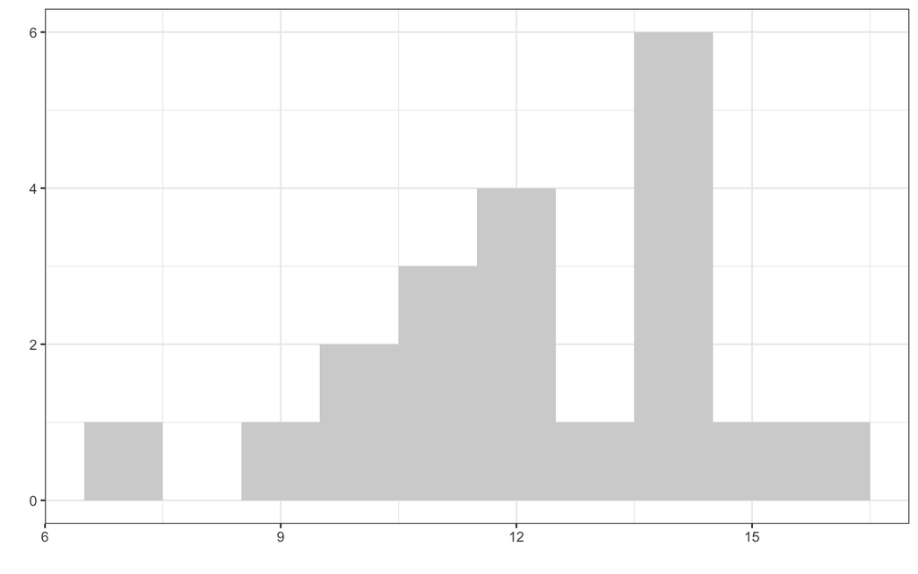

```r
set.seed(10)
data.frame(sum = replicate(20, sum(sample(box, 20, rep = T)))) %>%
  ggplot(., aes(sum)) +
  geom_histogram(bins = 10, fill = "lightgrey") +
  labs(x = "", y = "") +
  theme_bw()
```

6. If we take a larger number of draws (1000), what shape do we expect the distribution of the sum or proportion to have? What theorem formalizes this result? Demonstrate by simulation.

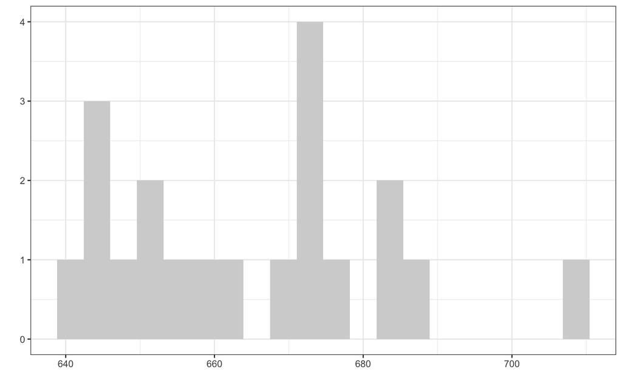

```r
set.seed(10)
data.frame(sum = replicate(20, sum(sample(box, 1000, rep = T)))) %>%
  ggplot(., aes(sum)) +
  geom_histogram(bins = 20, fill = "lightgrey") +
  labs(x = "", y = "") +
  theme_bw()
```